# Iris dataset

Here we apply various techniques to perform regression and classification tasks on the famous iris dataset.

See: https://www.kaggle.com/datasets/vikrishnan/iris-dataset

- We use sklearn's implementation of linear regression to predict one of the characteristics of the flower, with one-hot encoding accounting for the different flower types.
- We then use sklearn's implementation of logistic regression to predict the flower type, correctly classifying all but 1 sample in the test set.
- We implement our own version of linear regression to replicate the sklearn results.
- Finally, we implement gaussian discrimative analysis and see how it performs compared to logistic regression.

### Imports

```python
import pandas as pd
import matplotlib.pyplot as plt
from sklearn.decomposition import PCA
from sklearn.preprocessing import OneHotEncoder
from sklearn import linear_model
from sklearn.model_selection import train_test_split
from sklearn.metrics import mean_squared_error, confusion_matrix
from sklearn import preprocessing
from sklearn.metrics import ConfusionMatrixDisplay
from scipy.stats import multivariate_normal
import numpy as np
import collections
```

### Load the data

```python
iris = pd.read_csv("iris.csv")
```

```python
iris
```

|  | sepal_length | sepal_width | petal_length | petal_width | species |
| --- | --- | --- | --- | --- | --- |
| 0 | 5.1 | 3.5 | 1.4 | 0.2 | setosa |
| 1 | 4.9 | 3.0 | 1.4 | 0.2 | setosa |
| 2 | 4.7 | 3.2 | 1.3 | 0.2 | setosa |
| 3 | 4.6 | 3.1 | 1.5 | 0.2 | setosa |
| 4 | 5.0 | 3.6 | 1.4 | 0.2 | setosa |
| ... | ... | ... | ... | ... | ... |
| 145 | 6.7 | 3.0 | 5.2 | 2.3 | virginica |
| 146 | 6.3 | 2.5 | 5.0 | 1.9 | virginica |
| 147 | 6.5 | 3.0 | 5.2 | 2.0 | virginica |
| 148 | 6.2 | 3.4 | 5.4 | 2.3 | virginica |
| 149 | 5.9 | 3.0 | 5.1 | 1.8 | virginica |

150 rows × 5 columns

### Visualise 2 features

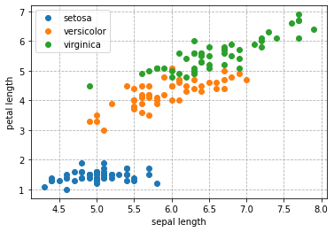

```python
for name, group in iris.groupby("species"):
    plt.plot(group.sepal_length, group.petal_length,
             marker="o", linestyle='', label=name)
plt.xlabel("sepal length")
plt.ylabel("petal length")
plt.grid(linestyle="--")
plt.legend()
```

### Visualise all features using dimensionality reduction (PCA)

```python
lower_d = PCA(n_components=2) \
  .fit_transform(iris.drop(['species'], axis=1))
```

```python
lower_d = pd.DataFrame(data=lower_d, columns=["pca1", "pca2"])
lower_d["species"] = iris["species"]
lower_d
```

|  | pca1 | pca2 | species |
| --- | --- | --- | --- |
| 0 | -2.684207 | 0.326607 | setosa |
| 1 | -2.715391 | -0.169557 | setosa |
| 2 | -2.889820 | -0.137346 | setosa |
| 3 | -2.746437 | -0.311124 | setosa |
| 4 | -2.728593 | 0.333925 | setosa |
| ... | ... | ... | ... |
| 145 | 1.944017 | 0.187415 | virginica |
| 146 | 1.525664 | -0.375021 | virginica |
| 147 | 1.764046 | 0.078519 | virginica |
| 148 | 1.901629 | 0.115877 | virginica |
| 149 | 1.389666 | -0.282887 | virginica |

150 rows × 3 columns

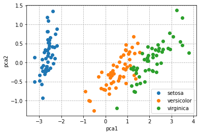

```python
for name, group in lower_d.groupby("species"):
    plt.plot(group.pca1, group.pca2,
             marker="o", linestyle='', label=name)
plt.xlabel("pca1")
plt.ylabel("pca2")
plt.grid(linestyle="--")
plt.legend()
```